[output not shown]

# Question 1

## 1

```r
bisection_method <- function(f, a, b, tol = 1e-8, max_iter = 1000) {
  # A short description of the function: Solves a root-finding problem using the Bisection method
  # Args:
  # f: Function to find the root of
  # a: Left endpoint of the interval (numeric)
  # b: Right endpoint of the interval (numeric)
  # tol: Tolerance for stopping criterion (numeric, default is 1e-8)
  # max_iter: Maximum number of iterations allowed (integer, default is 1000)
  # Return:
  # List of size 2:
  #   root: Approximate root of the function (numeric)
  #   iter: Number of iterations to find the root (numeric)

  if (f(a) * f(b) > 0) {
    stop("The function should have opposite signs at the interval endpoints.")
  }

  iter <- 0
  while (abs(b - a) > tol && iter < max_iter) {
    c <- (a + b) / 2

    if (identical(all.equal(f(c), 0), TRUE)) {
      break
    }

    if (f(a) * f(c) < 0) {
      b <- c
    } else {
      a <- c
    }

    iter <- iter + 1
  }

  root <- (a + b) / 2
  list(root = root, iter = iter)
}

# Equation (a)
f1 <- function(x) {
  x^3 + 23
}

# Equation (b)
f2 <- function(x) {
  x^x - 18
}

# Equation (c)
f3 <- function(x) {
  exp(-x^2) - 1/10
}
```

## 1.1a

For equation (a), the interval is [-5, 0] and the estimated number of iterations required is 29

```r
root_a <- bisection_method(f1, -5, 0)
cat("Root of equation (a):", root_a$root, "\n")
```

```
## Root of equation (a): -2.843867
```

```r
cat("Iterations:", root_a$iter, "\n")
```

```
## Iterations: 29
```

## 1.1b

For equation (b), the interval is [2, 3] and the estimated number of iterations required is 27

```r
root_b <- bisection_method(f2, 2, 3)
cat("Root of equation (b):", root_b$root, "\n")
```

```
## Root of equation (b): 2.803663
```

```r
cat("Iterations:", root_b$iter, "\n")
```

```
## Iterations: 27
```

## 1.1c

```r
root_c <- bisection_method(f3, 0, 2)
cat("Root of equation (c):", root_c$root, "\n")
```

```
## Root of equation (c): 1.517427
```

```r
cat("Iterations:", root_c$iter, "\n")
```

```
## Iterations: 23
```

To find g(x), we can rearrange (b) to solve for x.

2. = x^x - 18 = 0  
   -> x^x = 18  
   xlog(x) = log(18)  
   log(x) = log(18^(1/x))  
   x = 18^(1/x)

Thus, our g(x) = 18^(1/x).

Algorithm for Fixed Point Iteration method:

Set the initial guess x0 and the stopping criteria (tolerance and maximum iterations).  
For each iteration,  
Compute the next value x1 = g(x0).  
Check for convergence: If |x1 - x0| < tolerance, then the method has converged, and x1 is the approximate root. Otherwise, set x0 = x1 and repeat.

## 1.2

```r
fixed_point_iteration <- function(g, x0, tol = 1e-8, max_iter = 1000) {
  # A short description of the function: Solves a root-finding problem using the Fixed Point Iteration method
  # Args:
  # g: Function derived from the original equation f(x) = 0
  # x0: Initial guess (numeric)
  # tol: Tolerance for stopping criterion (numeric, default is 1e-8)
  # max_iter: Maximum number of iterations allowed (integer, default is 1000)
  # Return:
  # root: Approximate root of the function (numeric)

  iter <- 0

  while (iter < max_iter) {
    x1 <- g(x0)
    if (abs(x1 - x0) < tol) {
      break
    }
    x0 <- x1
    iter <- iter + 1
  }
  root <- x1
  root
}

# Define g(x) for equation (b): x^x - 18 = 0
g_b <- function(x) {
  18^(1/x)
}

# Initial guess
x0_b <- 2.5

# Solve
root_b_fixed_point <- fixed_point_iteration(g_b, x0_b)
cat("Root of equation (b) using Fixed Point Iteration:", root_b_fixed_point, "\n")
```

```
## Root of equation (b) using Fixed Point Iteration: 1.658585
```

Note: I was not able to get the function g(x) to converge onto the root. It appears that it has a harmonic convergence between 1.658585 and 5.712594 as g(1.658585) = 5.712594 and g(5.712594) = 1.658585. I tried various other forms of g(x), such as:  
x * log(x) - 18 + x, but this restricts negative inputs and, given an initial guess close to the root, will become negative on the second iteration, resulting in NaN values.  
x^x - 18 + x does not work as a negative input to x^x is treated in R as a complex number, so this also came up with NaN values.

I have verified that g(x) crosses the root at x = y with a graphing calculator, and performing a linear transformation on g(x) such as 2 * g(x) ends up in a function that converges, yet it does not provide the correct root, and I could not figure out how to inverse the transformation to get the correct answer.

## 1.3a

The function to find the square root using Newton’s method can be defined as f(x) = x^2 - a = 0. Where f’(x) = 2x, and,

x1 = x0 - f(x0) / f’(x0).

Algorithm for Newton’s Method:

Initialize x0 as half of a.  
Set the iteration counter, iter, to 0.  
While iter is less than iter_max:  
Update the estimate x1 using the formula x1 = x0 - (x0^2 - a) / (2 * x0).  
If verbose is TRUE, print the iteration number, current estimate, and the difference between the current and previous estimate.  
Check if the absolute difference between x1 and x0 is less than tol. If so, break the loop.  
Set x0 to x1.  
Increment the iteration counter, iter, by 1.  
Return x1, the final estimate of the square root.

## 1.3b

```r
sqrt_5 <- get_sqrt(5, verbose = TRUE)
```

```
## Iteration: 1 Current estimate: 2.25
## Iteration: 2 Current estimate: 2.236111
## Iteration: 3 Current estimate: 2.236068
## Iteration: 4 Current estimate: 2.236068
```

```r
cat("Square root of 5:", sqrt_5, "\n")
```

```
## Square root of 5: 2.236068
```

## 1.3c

The program would change by adding an additional parameter for the root we want to take (root), and then using that parameter to form our f(x) and f’(x), where f(x) = x0^root - a, and f’(x) = root * x0^(root-1).

The iterative equation would then be: g(x) = x0 - (x0^root - a)/(root * x0^(root-1)).

## 1.3d

Algorithm for get_abroot() function:

Initialize x0 as half of a.  
Set the iteration counter, iter, to 0.  
While iter is less than iter_max:  
Update the estimate x1 using the formula x1 = x0 - (x0^root - a) / (root * x0^(root - 1)).  
If verbose is TRUE, print the iteration number, current estimate, and the difference between the current and previous estimate.  
Check if the absolute difference between x1 and x0 is less than tol. If so, break the loop. Set x0 to x1.  
Increment the iteration counter, iter, by 1.  
Return x1, the final estimate of the arbitrary root.

```r
cube_root_8 <- get_abroot(8, 3, verbose = TRUE)
```

```
## Iteration: 1 Current estimate: 2.833333
## Iteration: 2 Current estimate: 2.221069
## Iteration: 3 Current estimate: 2.021274
## Iteration: 4 Current estimate: 2.000223
## Iteration: 5 Current estimate: 2
## Iteration: 6 Current estimate: 2
## Iteration: 7 Current estimate: 2
```

```r
cat("Cube root of 8:", cube_root_8, "\n")
```

```
## Cube root of 8: 2
```

## 1.3e

```r
seventh_root_13 <- get_abroot(13, 7, verbose = TRUE)
```

```
## Iteration: 1 Current estimate: 5.571453
## Iteration: 2 Current estimate: 4.775593
## Iteration: 3 Current estimate: 4.093522
## Iteration: 4 Current estimate: 3.509128
## Iteration: 5 Current estimate: 3.008819
## Iteration: 6 Current estimate: 2.581491
## Iteration: 7 Current estimate: 2.218981
## Iteration: 8 Current estimate: 1.917541
## Iteration: 9 Current estimate: 1.680964
## Iteration: 10 Current estimate: 1.523144
## Iteration: 11 Current estimate: 1.454282
## Iteration: 12 Current estimate: 1.442842
## Iteration: 13 Current estimate: 1.442563
## Iteration: 14 Current estimate: 1.442563
## Iteration: 15 Current estimate: 1.442563
```

```r
cat("Seventh root of 13:", seventh_root_13, "\n")
```

```
## Seventh root of 13: 1.442563
```

## 1.3f

```r
result <- get_abroot_with_errors(13, 7, verbose = TRUE)
```

```
## Iteration: 1 Current estimate: 5.571453 Error: 4.12889
## Iteration: 2 Current estimate: 4.775593 Error: 3.33303
## Iteration: 3 Current estimate: 4.093522 Error: 2.650959
## Iteration: 4 Current estimate: 3.509128 Error: 2.066565
## Iteration: 5 Current estimate: 3.008819 Error: 1.566256
## Iteration: 6 Current estimate: 2.581491 Error: 1.138928
## Iteration: 7 Current estimate: 2.218981 Error: 0.7764184
## Iteration: 8 Current estimate: 1.917541 Error: 0.4749779
## Iteration: 9 Current estimate: 1.680964 Error: 0.238401
## Iteration: 10 Current estimate: 1.523144 Error: 0.08058133
## Iteration: 11 Current estimate: 1.454282 Error: 0.01171947
## Iteration: 12 Current estimate: 1.442842 Error: 0.0002795527
## Iteration: 13 Current estimate: 1.442563 Error: 1.624387e-07
## Iteration: 14 Current estimate: 1.442563 Error: 5.484502e-14
## Iteration: 15 Current estimate: 1.442563 Error: 0
```

```r
cat("Seventh root of 13:", result$root, "\n")
```

```
## Seventh root of 13: 1.442563
```

```r
cat("Errors from e1 to e4:", result$errors[1:4], "\n")
```

```
## Errors from e1 to e4: 4.12889 3.33303 2.650959 2.066565
```

# 2

##a  
To find the minimum of the function f(x) = x^n - nalog(x), we need to find the critical points where the first derivative f’(x) is equal to 0 and the second derivative f’’(x) is greater than 0.

First derivative:  
f’(x) = nx^(n-1) - na/x

Second derivative:  
f’’(x) = n(n-1)x^(n-2) + na/x^2

Now let’s set f’(x) = 0,

0 = nx^(n-1) - na/x  
x^(n-1) = a/x  
(n-1)log(x) = log(a/x)  
nlog(x) - log(x) = log(a) - log(x)  
log(x) = log(a^(1/n))  
x = a^(1/n)

Hence, f(x) = 0 when x = a^(1/n), now the second derivative must be greater than 0 at those points to be a minimum.

Since n > 0, a > 0, and x > 0, we know that f’’(x) > 0 for all instances where x = a^(1/n). Hence our minimum is found at x = a^(1/n).

##b  
Newton’s method for finding the minimum involves iterating the following formula: x1 = x0 - f’(x0) / f’’(x0)

Therefore,

x1 = x0 - (nx0^(n-1) - na/x0) / (n(n-1)x0^(n-2) + na/x0^2))

##c

```r
f_expr <- expression(x^n - n*alpha*log(x))
min_f <- get_min(f_expr, x0 = 1, n = 2, alpha = 3)
cat("Minimum of f for n = 2 and α = 3:", min_f, "\n")
```

```
## Minimum of f for n = 2 and α = 3: 1.732051
```

## d

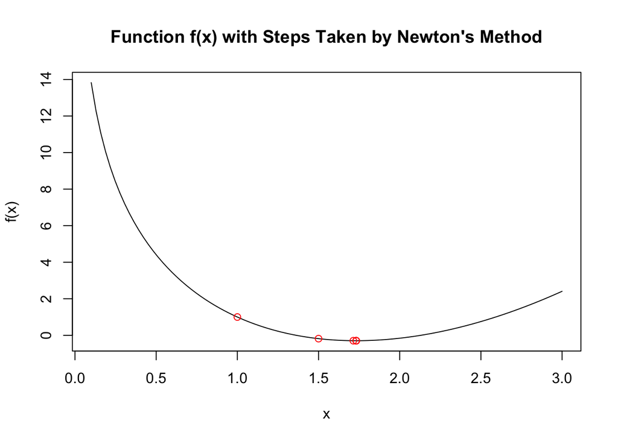

```r
result <- get_min_with_steps(f_expr, x0 = 1, n = 2, alpha = 3)

x_vals <- seq(0.1, 3, length.out = 100)
y_vals <- sapply(x_vals, function(x) with(list(x = x, n = 2, alpha = 3), eval(f_expr)))
steps_y_vals <- sapply(result$steps, function(x) with(list(x = x, n = 2, alpha = 3), eval(f_expr)))

plot(x_vals, y_vals, type = "l", main = "Function f(x) with Steps Taken by Newton's Method", xlab = "x", ylab = "f(x)")
points(result$steps, steps_y_vals, col = "red")
```